# Polynomial Regression

###### Bluffing detector

A potential employee told his new company that his current salary is $250k, the human resource retrieved the salary amount associated position levels in his previous company. The potential new employee has a position level 7.5, we would like to build a salary bluffing detector to see if he told the truth.

```python
# importing libraries
import numpy as np
import pandas as pd
import matplotlib.pyplot as plt
import os
```

```python
os.chdir('C:\\Users\\Wale\\Machine learning data')
```

```python
data = pd.read_csv("Position_Salaries.csv")
```

```python
data
```

|  | Position | Level | Salary |
| --- | --- | --- | --- |
| 0 | Business Analyst | 1 | 45000 |
| 1 | Junior Consultant | 2 | 50000 |
| 2 | Senior Consultant | 3 | 60000 |
| 3 | Manager | 4 | 80000 |
| 4 | Country Manager | 5 | 110000 |
| 5 | Region Manager | 6 | 150000 |
| 6 | Partner | 7 | 200000 |
| 7 | Senior Partner | 8 | 300000 |
| 8 | C-level | 9 | 500000 |
| 9 | CEO | 10 | 1000000 |

```python
# Matrix of features
X = data.iloc[:,1:2]
X
```

|  | Level |
| --- | --- |
| 0 | 1 |
| 1 | 2 |
| 2 | 3 |
| 3 | 4 |
| 4 | 5 |
| 5 | 6 |
| 6 | 7 |
| 7 | 8 |
| 8 | 9 |
| 9 | 10 |

```python
y =data.iloc[:,2:]
y
```

|  | Salary |
| --- | --- |
| 0 | 45000 |
| 1 | 50000 |
| 2 | 60000 |
| 3 | 80000 |
| 4 | 110000 |
| 5 | 150000 |
| 6 | 200000 |
| 7 | 300000 |
| 8 | 500000 |
| 9 | 1000000 |

We would not be splitting the data into a training set and test set because we don't have a lot of data. So we would train the model with all the data and predict with the new data 7.5.

```python
# Fitting the data with a simple regression model
from sklearn.linear_model import LinearRegression
regressor = LinearRegression()
# Fit the model with all the data
regressor.fit(X,y)
```

```
LinearRegression(copy_X=True, fit_intercept=True, n_jobs=None, normalize=False)
```

```python
# Predictin the potential employee salary at level 7.5
y_pred = regressor.predict([[7.5]])
y_pred
```

```
array([[411257.57575758]])
```

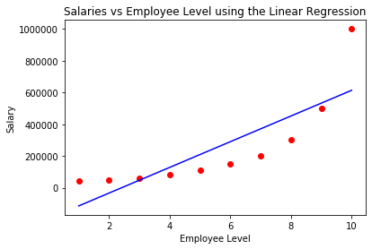

```python
# visualising the Linear Model
plt.scatter(X, y, color="red")
# regression line
plt.plot(X,regressor.predict(X), color = "blue" )
# add a title
plt.title("Salaries vs Employee Level using the Linear Regression")
plt.xlabel("Employee Level")
plt.ylabel("Salary")
plt.show()
```

##### Polynomial of Degree 2

```python
# fitting the polynomial Regression to the Data
from sklearn.preprocessing import PolynomialFeatures
poly_reg = PolynomialFeatures(degree = 2)
```

```python
# transforming the matrics of features X into the matrics of features X poly for the polynomial model
X_poly = poly_reg.fit_transform(X)
X_poly
```

```
array([[  1.,   1.,   1.],
       [  1.,   2.,   4.],
       [  1.,   3.,   9.],
       [  1.,   4.,  16.],
       [  1.,   5.,  25.],
       [  1.,   6.,  36.],
       [  1.,   7.,  49.],
       [  1.,   8.,  64.],
       [  1.,   9.,  81.],
       [  1.,  10., 100.]])
```

```python
poly_regression = LinearRegression()
poly_regression.fit(X_poly , y)
```

```
LinearRegression(copy_X=True, fit_intercept=True, n_jobs=None, normalize=False)
```

```python
# Predictin the potential employee salary at level 7.5
y_pred1 = poly_regression.predict(poly_reg.fit_transform([[7.5]]))
y_pred1
```

```
array([[328672.34848485]])
```

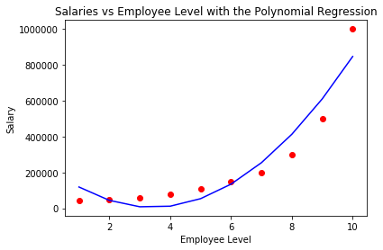

```python
# visualising the polynomial Model
plt.scatter(X, y, color="red")
# regression line
plt.plot(X,poly_regression.predict(poly_reg.fit_transform(X)), color = "blue" )
# add a title
plt.title("Salaries vs Employee Level with the Polynomial Regression")
plt.xlabel("Employee Level")
plt.ylabel("Salary")
plt.show()
```

##### Polynomial with degree 3

```python
# fitting the polynomial Regression to the Data
from sklearn.preprocessing import PolynomialFeatures
poly_reg = PolynomialFeatures(degree = 3)
```

```python
# transforming the matrics of features X into the matrics of features X poly for the polynomial model
X_poly = poly_reg.fit_transform(X)
X_poly
```

```
array([[   1.,    1.,    1.,    1.],
       [   1.,    2.,    4.,    8.],
       [   1.,    3.,    9.,   27.],
       [   1.,    4.,   16.,   64.],
       [   1.,    5.,   25.,  125.],
       [   1.,    6.,   36.,  216.],
       [   1.,    7.,   49.,  343.],
       [   1.,    8.,   64.,  512.],
       [   1.,    9.,   81.,  729.],
       [   1.,   10.,  100., 1000.]])
```

```python
poly_regression = LinearRegression()
poly_regression.fit(X_poly , y)
```

```
LinearRegression(copy_X=True, fit_intercept=True, n_jobs=None, normalize=False)
```

```python
# Predictin the potential employee salary at level 7.5
y_pred1 = poly_regression.predict(poly_reg.fit_transform([[7.5]]))
y_pred1
```

```
array([[240915.35547786]])
```

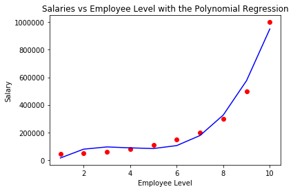

```python
# visualising the Linear Model
plt.scatter(X, y, color="red")
# regression line
plt.plot(X,poly_regression.predict(poly_reg.fit_transform(X)), color = "blue" )
# add a title
plt.title("Salaries vs Employee Level with the Polynomial Regression")
plt.xlabel("Employee Level")
plt.ylabel("Salary")
plt.show()
```

##### Polynomial with degree 4

```python
# fitting the polynomial Regression to the Data
from sklearn.preprocessing import PolynomialFeatures
poly_reg = PolynomialFeatures(degree = 4)
```

```python
# transforming the matrics of features X into the matrics of features X poly for the polynomial model
X_poly = poly_reg.fit_transform(X)
X_poly
```

```
array([[1.000e+00, 1.000e+00, 1.000e+00, 1.000e+00, 1.000e+00],
       [1.000e+00, 2.000e+00, 4.000e+00, 8.000e+00, 1.600e+01],
       [1.000e+00, 3.000e+00, 9.000e+00, 2.700e+01, 8.100e+01],
       [1.000e+00, 4.000e+00, 1.600e+01, 6.400e+01, 2.560e+02],
       [1.000e+00, 5.000e+00, 2.500e+01, 1.250e+02, 6.250e+02],
       [1.000e+00, 6.000e+00, 3.600e+01, 2.160e+02, 1.296e+03],
       [1.000e+00, 7.000e+00, 4.900e+01, 3.430e+02, 2.401e+03],
       [1.000e+00, 8.000e+00, 6.400e+01, 5.120e+02, 4.096e+03],
       [1.000e+00, 9.000e+00, 8.100e+01, 7.290e+02, 6.561e+03],
       [1.000e+00, 1.000e+01, 1.000e+02, 1.000e+03, 1.000e+04]])
```

```python
poly_regression = LinearRegression()
poly_regression.fit(X_poly , y)
```

```
LinearRegression(copy_X=True, fit_intercept=True, n_jobs=None, normalize=False)
```

```python
# Predictin the potential employee salary at level 7.5
y_pred1 = poly_regression.predict(poly_reg.fit_transform([[7.5]]))
y_pred1
```

```
array([[225126.29297782]])
```

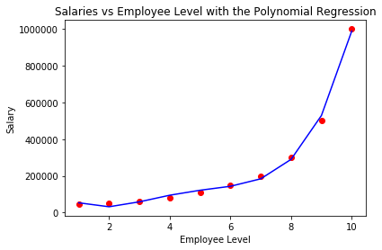

```python
# visualising the Linear Model
plt.scatter(X, y, color="red")
# regression line
plt.plot(X,poly_regression.predict(poly_reg.fit_transform(X)), color = "blue" )
# add a title
plt.title("Salaries vs Employee Level with the Polynomial Regression")
plt.xlabel("Employee Level")
plt.ylabel("Salary")
plt.show()
```

From the graphs and results above we can see the relationship between the position of employees and their salaries.So, a polynomial regression fits better.As the degrees increases the curve fits much better on the data.

We can conclude that the most accurate polynomial is of degree 4 and we can also say that the employee was bluffing. From our predictions an employee of level 7.5 from his previous place of work is paid about 225k, so he lied when he claimed his salary was 250K per year.